# Ciclos de vida pieza de Metal

Este conjunto de datos, disponible en el objeto **Biaxial** del *paquete ssym*, describe la vida (Life), en número de ciclos, de una pieza de metal, y la cantidad de trabajo por ciclo (Work). El objetivo del análisis consiste en explicar las diferencias entre la vida de las piezas de metal usando las diferencias en el trabajo por ciclo al que fueron expuestas.

```r
#traer los datos
library(ssym)
data("Biaxial")
head(Biaxial)
```

```
  Work Life
1 11.5 3280
2 13.0 5046
3 14.3 1563
4 15.6 4707
5 16.0  977
6 17.3 2834
```

### (A) Análisis descriptivo

```r
summary(Biaxial)
```

```
      Work             Life
 Min.   : 11.50   Min.   : 125.0
 1st Qu.: 24.00   1st Qu.: 242.8
 Median : 33.20   Median : 566.0
 Mean   : 40.29   Mean   : 943.7
 3rd Qu.: 60.12   3rd Qu.:1086.2
 Max.   :100.50   Max.   :5046.0
```

Notamos que el rango de la variable *Life* es más amplio que el de la variable *Work,* además la media de los datos es bastante lejana de la mediana en *life* lo cual nos sugiere que se puede tener colas pesadas a la derecha para esta variable.

```r
library(moments)
skewness(Biaxial$Life)
```

```
[1] 2.274693
```

```r
kurtosis(Biaxial$Life)
```

```
[1] 8.013197
```

Usando las medidas de **asimetría** y **curtosis** para la variable *life* vemos que la está presenta asimetría positiva y presenta colas pesadas.

[figure not shown]

```r
library(ggplot2)
#gráfico
ggplot(Biaxial, aes(x = Life)) +
  geom_density() +
      labs(title = "Vida en # de ciclos",  # Agregar título
       x = "Cantida de trabajo por ciclo", y = "Densidad" #Eti de los ejes
       )
```

Esto parece sugerirnos que la **componente aletoria** adecuada para nuestra variable respuesta debe ser estrictamente positiva y sesgada a la derecha por ende posibles candidatos fuertes son **Gamma o Inversa gaussiana o Log-Normal**.

### (B) Gráfico Life vs Work

primero miraremos dicha relación con los datos en la escala en la que está

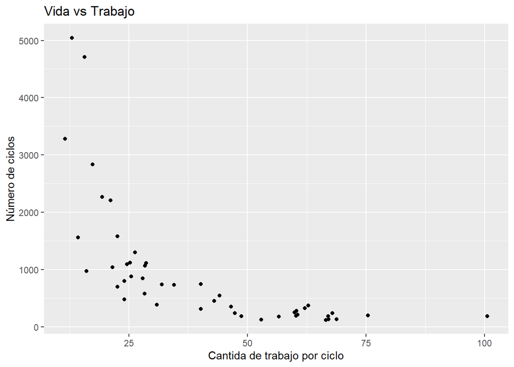

```r
ggplot(Biaxial, aes(x = Work, y = Life)) +
  geom_point()+
      labs(title = "Vida vs Trabajo",  # Agregar título
       x = "Cantida de trabajo por ciclo", y = "Número de ciclos" #Eti ejes
       )
```

Podemos ver que a medida que el trabajo por ciclo aumenta, el número de ciclos de vida de la pieza se ve disminuida. Además aparenta ser de manera *no lineal* recordando la forma de una función inversa $y=\frac{1}{x}$ .  
Ahora miraremos en escala $\ln$ para ambas variables

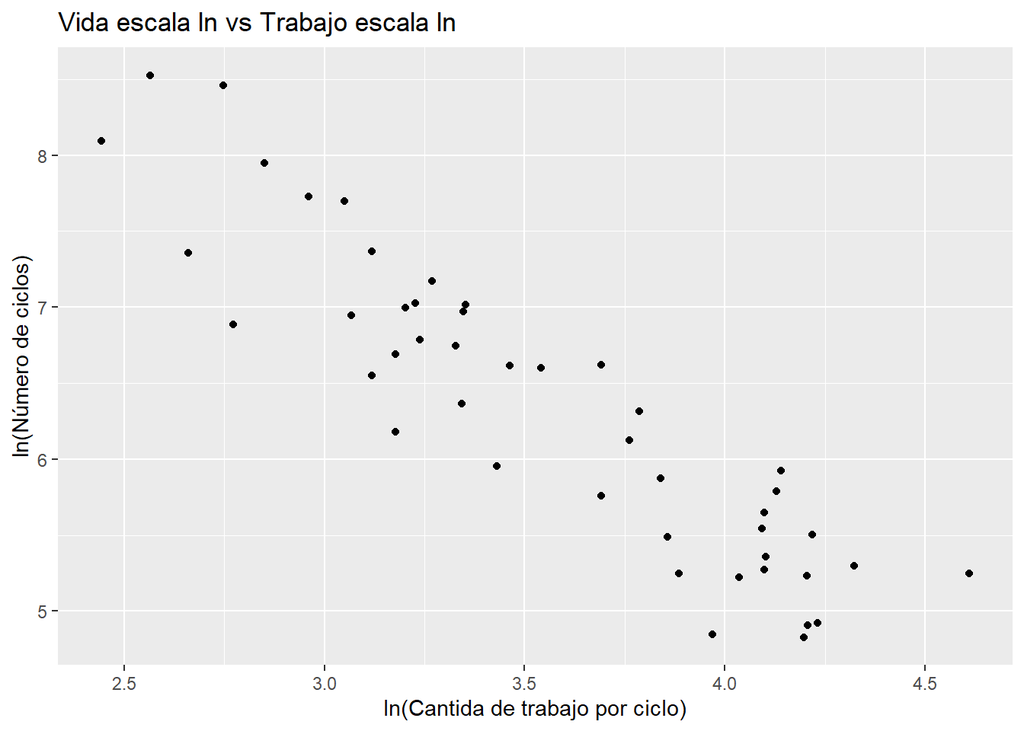

```r
ggplot(Biaxial, aes(x = log(Work), y = log(Life))) +
  geom_point()+
      labs(title = "Vida escala ln vs Trabajo escala ln", # título
       x = "ln(Cantida de trabajo por ciclo)", y = "ln(Número de ciclos)" #Eti ejes
       )
```

Para la gráfica donde se lleva a escala logarítmica ambas variables vemos que se conserva la relación de que a medida que aumenta la cantidad de trabajo por ciclo disminuye el número de ciclos de vida de la pieza de metal. Además en esta escala la relación aparenta comportamiento *lineal* recordando una función del tipo $y=ax+b$.

### (C) Ajuste de modelos

1. $Y_i \overset{ind}{\sim} \text{Normal-Inversa}(\beta_1x_{i}^{\beta_2} , \sigma^2)$

Con lo anterior tenemos que $\omega_i=1$ para todo $i=1,\cdots,n$ , además $\phi = \sigma^2$ y $\mu_i=\beta_1x_{i}^{\beta_2}$. Ahora sabemos que para un modelo lineal generalizado **Normal-Inversa** se cumple que$g(\mu_i)=\beta_0+ \beta_1x_{i1}+ \cdots +\beta_px_{ip}$ por lo tanto para nuestro caso tenemos que si $g(\circ) = \ln(\circ)$ tenemos que:

$$\begin{equation*}
\begin{array}{rl}
\ln(\mu_i) & = \ln\left[\beta_1x_{i}^{\beta_2}\right] \\
& = \ln[\beta_1] + \beta_2\ln[x_i] \\
g(\mu_i) &= \beta_1^{*} + \beta_2\ln[x_i]
\end{array}
\end{equation*}$$

Así tenemos que el modelo se plantea de la siguiente manera

```r
Modelo1 <- glm(Life ~ log(Work), family=inverse.gaussian(log), data=Biaxial)
summary(Modelo1)
```

```
Call:
glm(formula = Life ~ log(Work), family = inverse.gaussian(log),
    data = Biaxial)

Coefficients:
            Estimate Std. Error t value Pr(>|t|)
(Intercept)  11.7484     0.5068   23.18  < 2e-16 ***
log(Work)    -1.5103     0.1280  -11.80 3.17e-15 ***
---
Signif. codes:  0 '***' 0.001 '**' 0.01 '*' 0.05 '.' 0.1 ' ' 1

(Dispersion parameter for inverse.gaussian family taken to be 0.0003385822)

    Null deviance: 0.074382  on 45  degrees of freedom
Residual deviance: 0.016942  on 44  degrees of freedom
AIC: 647.68

Number of Fisher Scoring iterations: 9
```

Podemos ver cómo los parámetros son significativos estadísticamente al $95\%$ de confianza pues su $p-valor < 0.05$, además la devianza del modelo con la variable *cantidad de trabajo por ciclo* es menor al modelo sin ella, por ende se puede explicar las variaciones en *life* con las variaciones en *Work*.  
**No obstante**, es necesario mirar otros modelos posibles a plantear y considerar los supuestos para los mismos, teniendo esto en mente procedemos de manera similar para los otros modelos posibles para este caso.

2. $Y_i = \beta_1x_{i}^{\beta_2}\epsilon_i$ en que $\epsilon_i \overset{ind}{\sim} \text{Gamma}(1, \sigma^2)$

Con lo anterior tenemos que $\omega_i=1$ para todo $i=1,\cdots,n$ , además $\phi = \sigma^2$ y $\mu_i=\beta_1x_{i}^{\beta_2}$. Ahora sabemos que para un modelo lineal generalizado **Gamma** se cumple que$g(\mu_i)=\beta_0+ \beta_1x_{i1}+ \cdots +\beta_px_{ip}$ por lo tanto para nuestro caso tenemos que si $g(\circ) = \ln(\circ)$ tenemos que cómo en el anterior caso:

$$g(\mu_i) = \beta_1^{*} + \beta_2\ln[x_i]$$

Así el modelo quedaría de la siguiente manera

```r
Modelo2 <- glm(Life ~ log(Work), family=Gamma(log), data=Biaxial)
summary(Modelo2)
```

```
Call:
glm(formula = Life ~ log(Work), family = Gamma(log), data = Biaxial)

Coefficients:
            Estimate Std. Error t value Pr(>|t|)
(Intercept)  12.4449     0.3869   32.16   <2e-16 ***
log(Work)    -1.6945     0.1076  -15.76   <2e-16 ***
---
Signif. codes:  0 '***' 0.001 '**' 0.01 '*' 0.05 '.' 0.1 ' ' 1

(Dispersion parameter for Gamma family taken to be 0.1554257)

    Null deviance: 46.9494  on 45  degrees of freedom
Residual deviance:  7.2105  on 44  degrees of freedom
AIC: 635.73

Number of Fisher Scoring iterations: 5
```

3. $Y_i = \beta_1x_{i}^{\beta_2} + \epsilon_i$ en que $\epsilon_i \overset{ind}{\sim} \text{Normal}(0, \sigma^2)$

$$g(\mu_i) = \beta_1^{*} + \beta_2\ln[x_i]$$

Así el modelo quedaría de la siguiente manera

```r
Modelo3 <- glm(Life ~ log(Work), family=gaussian(log), data=Biaxial)
summary(Modelo3)
```

```
Call:
glm(formula = Life ~ log(Work), family = gaussian(log), data = Biaxial)

Coefficients:
            Estimate Std. Error t value Pr(>|t|)
(Intercept)  12.5627     0.5453  23.039  < 2e-16 ***
log(Work)    -1.7213     0.1931  -8.912 2.06e-11 ***
---
Signif. codes:  0 '***' 0.001 '**' 0.01 '*' 0.05 '.' 0.1 ' ' 1

(Dispersion parameter for gaussian family taken to be 353347.5)

    Null deviance: 55570610  on 45  degrees of freedom
Residual deviance: 15547263  on 44  degrees of freedom
AIC: 722.16

Number of Fisher Scoring iterations: 5
```

4. $Y_i = \beta_1x_{i}^{\beta_2}\epsilon_i$ en que $\epsilon_i \overset{ind}{\sim} \text{Log-Normal}(1, \sigma^2)$

Con lo anterior tenemos que $\omega_i=1$ para todo $i=1,\cdots,n$ y $\tau_i=\beta_1x_{i}^{\beta_2}$. Ahora sabemos que para la regresión **Log-Normal** se cumple que $h(\tau_i)=\beta_0+ \beta_1x_{i1}+ \cdots +\beta_px_{ip}$ por lo tanto para nuestro caso tenemos que si $h(\circ) = \ln(\circ)$ tenemos que cómo en el anterior caso:

$$h(\tau_i) = \beta_1^{*} + \beta_2\ln[x_i]$$

Ahora para poder usar la teoría de modelos lineales generalizados establecemos la conexión que tiene la distribución **Log-Normal** con la **Normal** con esto podremos plantear el modelo. Por ende tenemos que si en la **Log-Normal** $h(\tau_i)= \ln(\tau_i)$ entonces en la **Normal** $g(\mu_i)=\mu_i$ cómo **función de enlace** y que la variable respuesta sería $\ln(Life)$ para el modelo **Normal** entonces:

```r
Modelo4 <- glm(log(Life) ~ log(Work), family=gaussian(identity),
               data=Biaxial)
summary(Modelo4)
```

```
Call:
glm(formula = log(Life) ~ log(Work), family = gaussian(identity),
    data = Biaxial)

Coefficients:
            Estimate Std. Error t value Pr(>|t|)
(Intercept)  12.2893     0.4058   30.28   <2e-16 ***
log(Work)    -1.6727     0.1128  -14.83   <2e-16 ***
---
Signif. codes:  0 '***' 0.001 '**' 0.01 '*' 0.05 '.' 0.1 ' ' 1

(Dispersion parameter for gaussian family taken to be 0.1709777)

    Null deviance: 45.119  on 45  degrees of freedom
Residual deviance:  7.523  on 44  degrees of freedom
AIC: 53.251

Number of Fisher Scoring iterations: 2
```

Ahora procedemos a **comparar** los modelos primero notamos que tres de ellos tiene cómo explicativa $\ln(x)$ y respuesta $y$ así entonces:

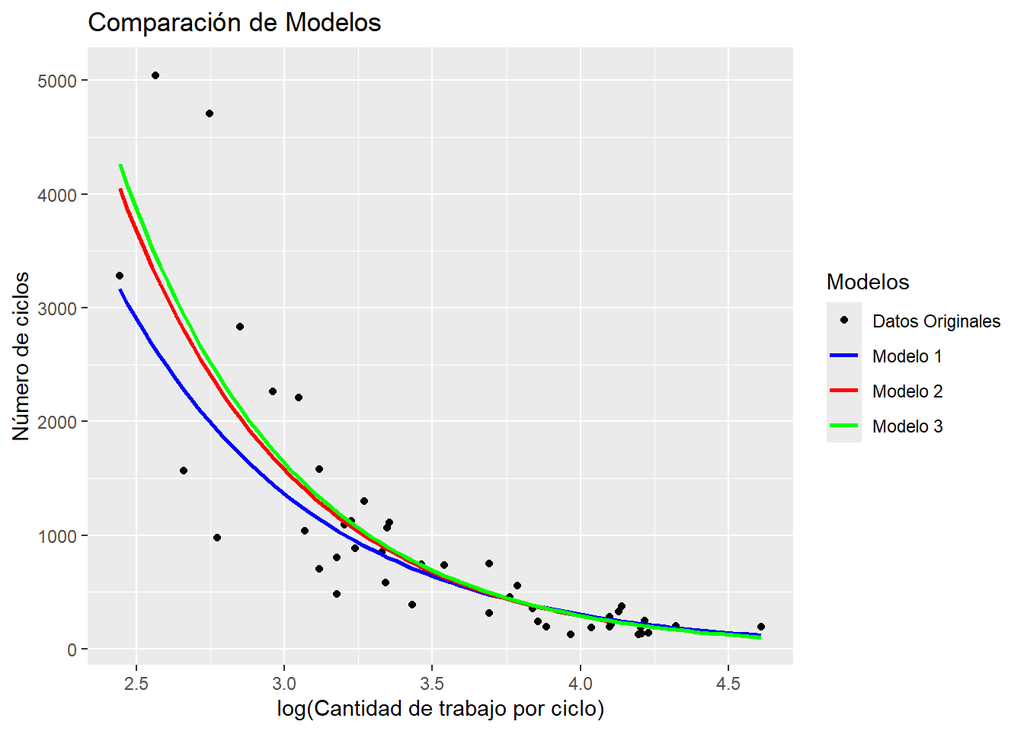

```r
# Gráfico base de dispersión
p <- ggplot(Biaxial, aes(x = log(Work), y = Life)) +
  geom_point(aes(color = "Data")) +  # Etiqueta para datos originales
  labs(title = "Comparación de Modelos",
       x = "log(Cantidad de trabajo por ciclo)", y = "Número de ciclos")

# Añadir líneas de regresión para cada modelo
p <- p +
  geom_smooth(aes(color = "Modelo 1"),
              method = "glm", formula = y ~ x, data = Biaxial,
              method.args = list(family = inverse.gaussian(link = "log")),
              se = FALSE) +
  geom_smooth(aes(color = "Modelo 2"),
              method = "glm", formula = y ~ x, data = Biaxial,
              method.args = list(family = Gamma(link = "log")),
              se = FALSE) +
  geom_smooth(aes(color = "Modelo 3"),
              method = "glm", formula = y ~ x, data = Biaxial,
              method.args = list(family = gaussian(link = "log")),
              se = FALSE)

# Ajustar nombres de las etiquetas en la leyenda
p + scale_color_manual(name = "Modelos",
                        values = c("Data" = "black", "Modelo 1" = "blue",
                                   "Modelo 2" = "red", "Modelo 3" = "green"),
                        labels = c("Datos Originales", "Modelo 1",
                                   "Modelo 2", "Modelo 3"))
```

Ahora para el ultimo modelo cómo tanto la variable explicativa cómo la respuesta están en escala $\ln$ tenemos que

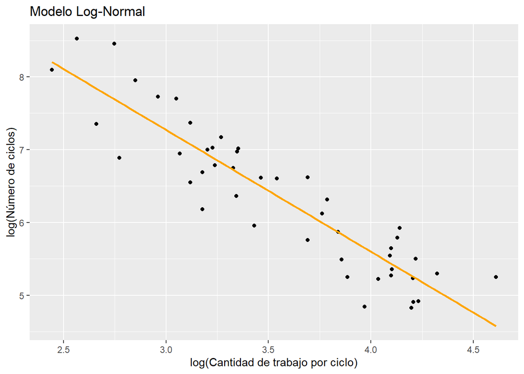

```r
#Gráfico base de dispersión
p <- ggplot(Biaxial, aes(x = log(Work), y = log(Life))) +
  geom_point() +
  labs(title = "Modelo Log-Normal",
       x = "log(Cantidad de trabajo por ciclo)",
       y = "log(Número de ciclos)")
# Añadir líneas de regresión para cada modelo
p + geom_smooth(method = "glm", formula = y ~ x, data = Biaxial,
              method.args = list(family = gaussian(link = "identity")),
              color = "orange", se = FALSE)
```

Vemos que para el caso de la *Log-Normal* aparenta un buen ajuste al modelo con los datos en escala $\ln$, pero tenemos que tener encuenta que por construcción este modelo necesita un ajuste para comparar por *cirterios de información*. Entonces procederemos a compara los modelos con los *criterios de información* y el *ajuste* de los datos con $R^2_{adj}$ para seleccionar el “mejor” modelo.

```r
library(knitr)
AIC <- c(AIC(Modelo1), AIC(Modelo2), AIC(Modelo3),
         AIC(Modelo4)+ (2*sum(log(Biaxial$Life))))
BIC <- c(BIC(Modelo1), BIC(Modelo2), BIC(Modelo3),
         BIC(Modelo4)++ (2*sum(log(Biaxial$Life))))
R2_adj <-  c(with(Modelo1,1-deviance*df.null/(null.deviance*df.residual)),
            with(Modelo2,1-deviance*df.null/(null.deviance*df.residual)),
            with(Modelo3,1-deviance*df.null/(null.deviance*df.residual)),
            with(Modelo4,1-deviance*df.null/(null.deviance*df.residual)))
Tabla <- data.frame(rbind(AIC,BIC,R2_adj))
names(Tabla) <- c("N-Inversa", "Gamma","Normal","Log-Nor")
knitr::kable(Tabla, digits = 3)
```

|  | N-Inversa | Gamma | Normal | Log-Nor |
| --- | --- | --- | --- | --- |
| AIC | 647.680 | 635.729 | 722.157 | 636.480 |
| BIC | 653.166 | 641.214 | 727.643 | 641.966 |
| R2_adj | 0.767 | 0.843 | 0.714 | 0.829 |

Vemos que por $R^2_{adj}$ el modelo **Gamma** presenta el valor más alto con $0.843$ , tambíen es el valor más bajo para *AIC* y *BIC,* por lo tanto lo tomaremos cómo el mejor modelo.

### (D) Nivel de significancia al $5\%$

Con le modelo seleccionado procederemos a realizar pruebas de significancia para el parámetro asociado a la variable explicativa entonces:

1. el modelo asociado a $H_0: \beta_2 = 0$

```r
#primero el modelo asociado a la hipotesis nula
Modelo0 <- glm(Life ~ 1, family=Gamma(log), data=Biaxial)
```

2. test de Wald

```r
library(glmtoolbox)
# wald
anova2(Modelo0,Modelo2, test='wald')
```

```
  Wald test

Model 1 :  Life ~ 1
Model 2 :  Life ~ log(Work)

        Chi    df  Pr(Chisq>)
1 vs 2 248.21   1   < 2.2e-16 ***
---
Signif. codes:  0 '***' 0.001 '**' 0.01 '*' 0.05 '.' 0.1 ' ' 1
```

3. Test de razón de verosimilitudes

```r
anova2(Modelo0,Modelo2, test='lr')
```

```
  Likelihood-ratio test

Model 1 :  Life ~ 1
Model 2 :  Life ~ log(Work)

        Chi    df  Pr(Chisq>)
1 vs 2 255.68   1   < 2.2e-16 ***
---
Signif. codes:  0 '***' 0.001 '**' 0.01 '*' 0.05 '.' 0.1 ' ' 1
```

Podemos concluir que para ambos test con un $\alpha = 0.05$ cómo los $p-valores$ de cada test respectivamente son menores que $\alpha$ se rechaza $H_0$, así la vida esperada de las piezas **si** depende de la cantidad de trabajo.

### (E) Análisis de diagnóstico

1. Análisis de residuales

   Primero usaremos los residuales de tipo **cuantil** para este análisis así

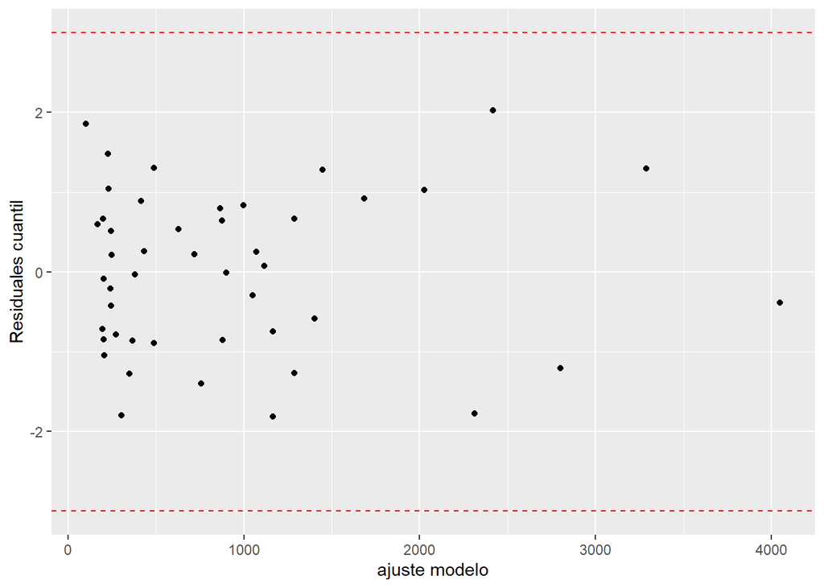

```r
Residuales <- residuals2(Modelo2,type="quantile")
#Gráifco
ggplot() +
  geom_point(aes(x = Modelo2$fitted.values, y = Residuales))+
      labs(x = "ajuste modelo",y = "Residuales cuantil" #Eti ejes
       )+
      geom_hline(yintercept = -3, linetype = "dashed", color = "red") +
      geom_hline(yintercept = 3, linetype = "dashed", color = "red")
```

Vemos que para el modelo **Gamma** los valores de los residuales no aparentan ningún patrón, además no superan los limites para creer que son lo suficientemente grandes cómo para causar problemas con el ajuste. Ahora para los residuales de tipo **cuantil** sabemos miraremos si siguen una distribución normal estándar así:

[output not shown]

[output cut: 94 more lines]

[output not shown]

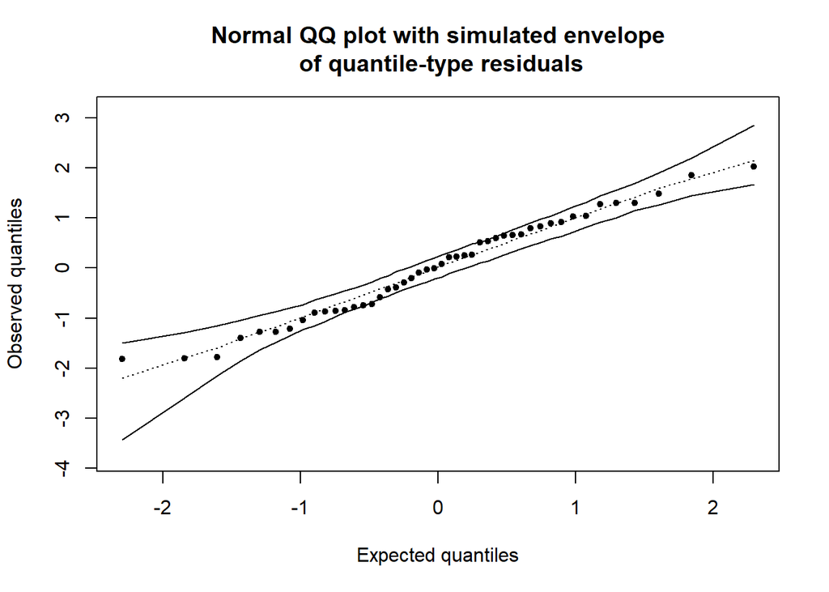

```r
glmtoolbox::envelope(Modelo2, type = "quantile", rep= 500)
```

Podemos ver que los valores de los residuales de tipo **cuantil** están entre las bandas en su mayoría se encuentra dentro de las bandas, algunos puntos se encuentra justo sobre la banda, aún así esto nos permite concluir que los residuos cumplen el supuesto y así el modelo está bien ajustado y cumple con los supuestos para los residuos.

2. Análisis de sensibilidad

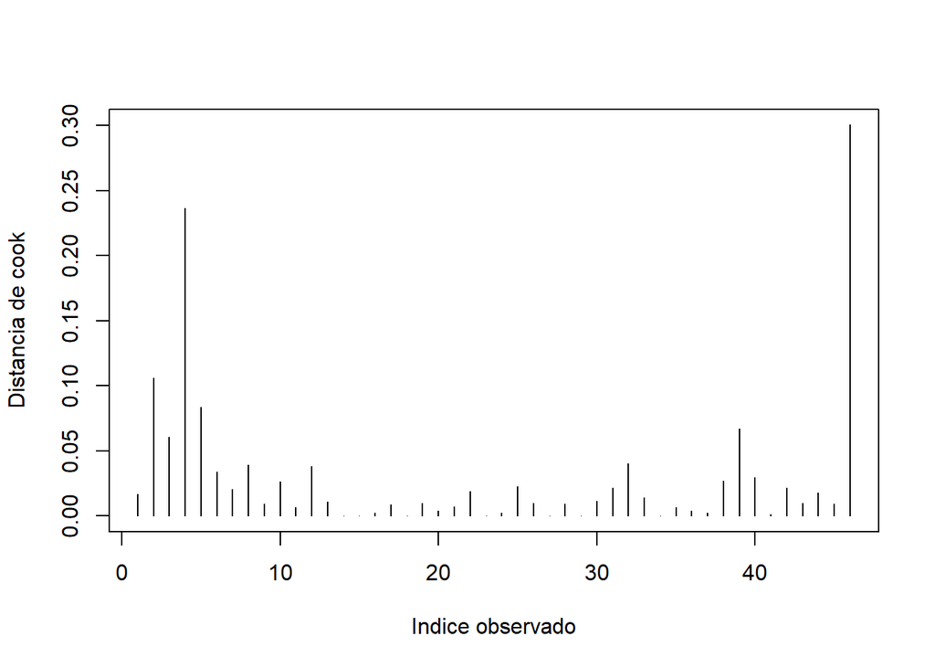

```r
cdi <- cooks.distance(Modelo2)
plot(cdi, type="h", xlab="Indice observado", ylab="Distancia de cook")
```

Vemos que se tienen $2$ valores que resaltan por su influencia los cuales son mayores a $0.15$

```r
which(cdi > 0.15)
```

```
 4 46
 4 46
```

los datos $4$ y $46$ son potencialmente influyentes así pasaremos a mira cuales causan el mayor cambio en las estimaciones de los $\hat{\beta}$

```r
infl <- c(4,46)
n <- length(infl)
metr <- chol2inv(chol(vcov(Modelo4)))
hm <- 2**n - 1
results <- matrix(0,nrow = hm,ncol=1)
id <- 1; nfil <- vector()
for (k in 1:n) {
      pos <- combn(n,k)
      for (l in 1:ncol(pos)) {
            Modemp <- update(Modelo4, subset=-pos[,l])
            difs <- coef(Modemp)- coef(Modelo4)
            results[id,1] <- t(difs)%*%metr%*%(difs)
            nfil <- c(nfil,paste(infl[pos[,l]], collapse = ","))
            id <- id + 1
      }
}
nfil[results==max(results)]
```

```
[1] "46"
```

Los cambios más grandes en las estimaciones de $\hat{\beta}$ se tienen cuando se saca el dato $46$ Ahora miraremos que tan significativo es este cambio, para ello primero los valores de los $\hat{\beta}$ para el modelo

```r
a <- round(summary(Modelo2)$coefficients, digits=5); a
```

```
            Estimate Std. Error   t value Pr(>|t|)
(Intercept) 12.44487    0.38695  32.16154        0
log(Work)   -1.69446    0.10755 -15.75463        0
```

Ahora las estimaciones retirando la pareja más influyente

```r
Modelo2_i <- update(Modelo2, subset=-c(46))
b <- round(summary(Modelo2_i)$coefficients, digits = 5); b
```

```
            Estimate Std. Error   t value Pr(>|t|)
(Intercept) 12.68431    0.38498  32.94773        0
log(Work)   -1.76781    0.10778 -16.40235        0
```

Notamos que los valores son bastantes parecidos, **no** se presenta cambios de signo y siguen siendo significativos así estos datos **no son** lo suficientemente influyentes cómo para retirarlos del modelo.

3. Parámetro de dispersión constante

```r
vdtest(Modelo2)
```

```
             Score test for varying dispersion parameter

          Statistic =  0.51727
 degrees of freedom =  1
            p-value =  0.47201
```

Vemos que el $p-valor$ es mayor a un $\alpha=0.05$ con esto podemos **no** tenemos evidencia estadística suficiente en contra de la hipótesis de que sea constante.

### (F) Interpretación estimaciones del parámetro

Cómo el modelo seleccionado fue **gamma** con función de enlace **log()** entonces recurriremos a lo siguientes:

$$\begin{equation*}
\begin{array}{rl}
\frac{\mu_{x\delta}}{\mu_x} &= \frac{\exp(\beta_1^{*}+\beta_2\ln(x\delta))}{\exp(\beta_1^{*}+\beta_2\ln(x)))} \\
& = \exp(\beta_2\ln(\delta)) \\
& = \delta^{\beta_2}
\end{array}
\end{equation*}$$

### (G) Estime punto no observado

Estime la vida esperada, en número de ciclos, de una pieza de metal cuando el trabajo por ciclo es $40$.

1. Manualmente

```r
exp(sum(coef(Modelo2)*c(1,log(40))))
```

```
[1] 489.9144
```

1. predict

```r
predict(Modelo2,newdata=data.frame(Work=40),type="response")
```

```
       1
489.9144
```

Se estima que el número de ciclos de vida sea aproximadamente $490$.